# U12 HW

Johnny Vogt

2025-11-15

## Exercise 1: Conceptual Questions

### A. Name at least two advantages that logistic regression has over LDA.

1. Logistic Regression have better fit with real-world data due to not assuming that predictors are normally distributed.
2. Logistic regression are able to work with non-linear relationships between predictors and response through transformations and interactions.

### B. Does logistic regression predict the binary outcome or does it predict something else? Explain.

Logistics Regression doesn’t predict an outcome, it predicts the probability of an binary outcome. The output of a logistic regression will give you a value between 0 and 1, which would represent the probability of a binary outcome.

###C. True or false? Multicollinearity is not typically an issue with LDA. However it is still an issue for logistic regression.

True, multicollinearity affect logistic regression more than a LDA model would. Having coefficients with high multicollineariyt could ead to unstable model results.

### D. Briefly explain the separability problem that multiple logistic regression can sometimes suffer from.

IN rare cases, when predictor variables seperate groups perfectly, logistic regression struggles. This is because coefficients go to infinity, which makes estimating impossible.

## Exercise 2: Natural Selection within House Sparrows

Hermon Bumpus conducted an observational study noting that not all house sparrows survived a severe winter storm in 1898. He collected the measurements on the dead sparrows and then subsequently obtained the same measurements on birds that survived the winter. The data set is located in the `Sleuth3` package. The following code loads the data in and makes some formatting changes to save the student some time. Use `?ex2016` to obtain additional detail on the predictors in the data set.

```r
library(Sleuth3)
bumpus<-ex2016
bumpus$Status.Num<-ifelse(bumpus$Status=="Survived",1,0)
bumpus$AG<-factor(bumpus$AG)
head(bumpus)
```

```
##     Status AG  TL  AE   WT   BH   HL   FL   TT   SK   KL Status.Num
## 1 Survived  1 154 241 24.5 31.2 0.69 0.67 1.02 0.59 0.83          1
## 2 Survived  1 160 252 26.9 30.8 0.74 0.71 1.18 0.60 0.84          1
## 3 Survived  1 155 243 26.9 30.6 0.73 0.70 1.15 0.60 0.85          1
## 4 Survived  1 154 245 24.3 31.7 0.74 0.69 1.15 0.58 0.84          1
## 5 Survived  1 156 247 24.1 31.5 0.71 0.71 1.13 0.57 0.82          1
## 6 Survived  1 161 253 26.5 31.8 0.78 0.74 1.14 0.61 0.89          1
```

```r
#?ex2016 to obtain details on the variables
```

### A. Perform an exploratory analysis of the data set to identify potential trends between the survival status and the predictors. At a minimum you should explore a scatter plot matrix for separability and for multicollinearity, and you should examine loess plots for the numeric variables and bar plots for the age categorical variable. Write a brief report of what you see. You do not need to consider interactions for this problem.

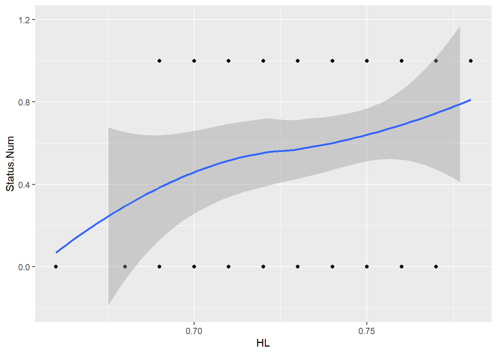

```r
library(ggplot2)
ggplot(bumpus,aes(x=HL,y=Status.Num))+geom_point()+
  geom_smooth(method="loess",size=1,span=1)+
  ylim(-.2,1.2)
```

As the HL incresases, the liklihood of survival increases. Birds with longers Humeruses have a higher probability of surviving winter.

### B. Fit a full model using all of the available predictors. Examine the VIFs of the model (same way you do for MLR) and perform the Hosmer-Lemeshow goodness of fit. Comment on what these outputs are telling us about the model fit. Some example code of implementing Hosmer-Lemeshow follows:

```r
mymodel<-glm(Status~AG+TL+AE+WT+BH+HL+FL+TT+SK+KL,data=bumpus,family="binomial")
summary(mymodel)
library(car)
vif(mymodel)
library(ResourceSelection)
hoslem.test(mymodel$y,fitted(mymodel))
```

[output not shown]

3. Provide a summary of what predictors are relevant to the sparrows survival by conducting a formal test at the 0.10 level for each one. For the significant ones, provide an interpretation of their effects in terms of odds ratio and provide a confidence interval.

Odds Ratio: TL = e^-0.73 = 0.48 WT = e^-0.89 = 0.41 HL = e^56.03 = 2.156*10^24 KL = e^23.56 = 1.65* 10^10

```r
mymodel<-glm(Status~AG+TL+AE+WT+BH+HL+FL+TT+SK+KL,data=bumpus,family="binomial")
confint(mymodel)
```

```
##                   2.5 %      97.5 %
## (Intercept) -24.1839865  80.3269794
## AG2          -1.2406092   1.4738374
## TL           -1.1618845  -0.4056171
## AE           -0.1615610   0.3429937
## WT           -1.6373321  -0.2817995
## BH           -0.6069954   1.7823683
## HL           -2.0009009 122.3352713
## FL          -70.0305379  56.8127298
## TT          -23.7711405  32.6162480
## SK          -31.4681966  77.4655279
## KL            1.4451576  49.3519995
```

```r
exp(confint(mymodel))
```

```
##                    2.5 %       97.5 %
## (Intercept) 3.140712e-11 7.683585e+34
## AG2         2.892080e-01 4.365957e+00
## TL          3.128960e-01 6.665654e-01
## AE          8.508146e-01 1.409160e+00
## WT          1.944982e-01 7.544249e-01
## BH          5.449859e-01 5.943917e+00
## HL          1.352134e-01 1.347514e+53
## FL          3.855883e-31 4.714711e+24
## TT          4.745968e-11 1.462367e+14
## SK          2.155440e-14 4.393911e+33
## KL          4.242521e+00 2.712071e+21
```

4. Although we most likely could reduce the model further, we have answered the main researchers questions by fitting a full model and reporting the results of the test. We can always reduce the model down to only the relevant predictors to make the model more interpretable. Do this now and provide an effects plot for the parsimonious model. Note that because this is additive, you can provide the effect plot for each predictor one at a time without losing much information. You do not need to add commentary to this question but examine the plots to make sure they make sense with your coefficients.

```r
mymodel_red <- glm(Status ~ TL +WT + HL + KL, data = bumpus, family = "binomial")
summary(mymodel_red)
```

```
##
## Call:
## glm(formula = Status ~ TL + WT + HL + KL, family = "binomial",
##     data = bumpus)
##
## Coefficients:
##             Estimate Std. Error z value Pr(>|z|)
## (Intercept)  49.9861    18.4879   2.704 0.006857 **
## TL           -0.6573     0.1683  -3.907 9.35e-05 ***
## WT           -0.7896     0.3097  -2.549 0.010800 *
## HL           72.3327    20.7640   3.484 0.000495 ***
## KL           27.3775    11.7780   2.324 0.020101 *
## ---
## Signif. codes:  0 '***' 0.001 '**' 0.01 '*' 0.05 '.' 0.1 ' ' 1
##
## (Dispersion parameter for binomial family taken to be 1)
##
##     Null deviance: 118.008  on 86  degrees of freedom
## Residual deviance:  68.612  on 82  degrees of freedom
## AIC: 78.612
##
## Number of Fisher Scoring iterations: 6
```

```r
library(effects)
```

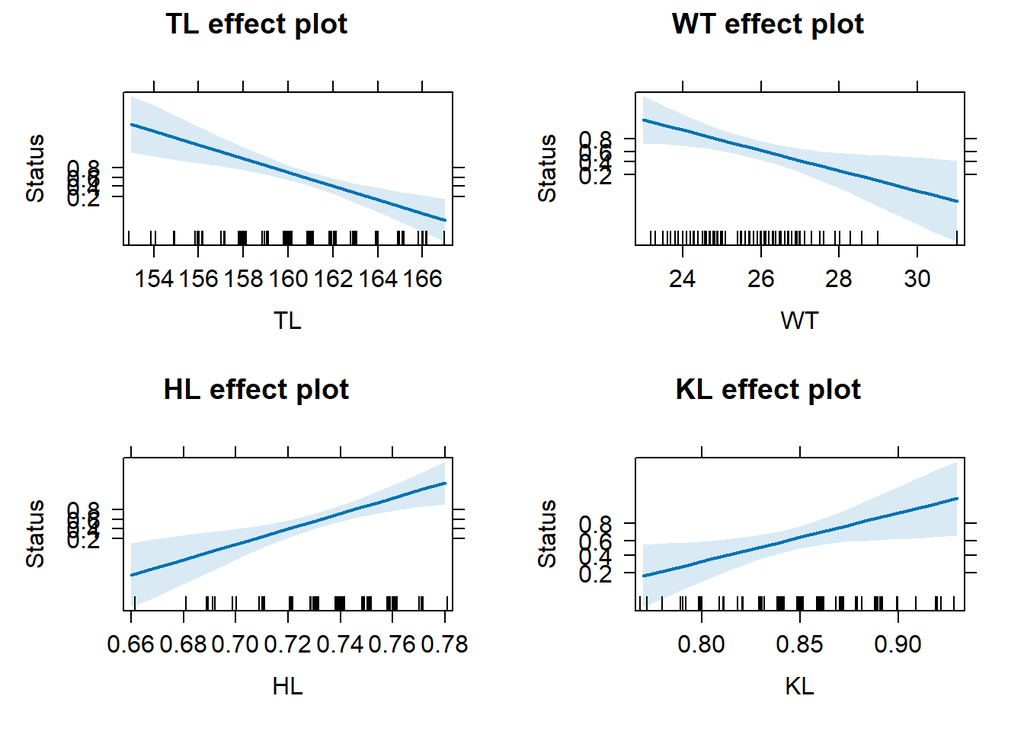

```r
plot(allEffects(mymodel_red))
```

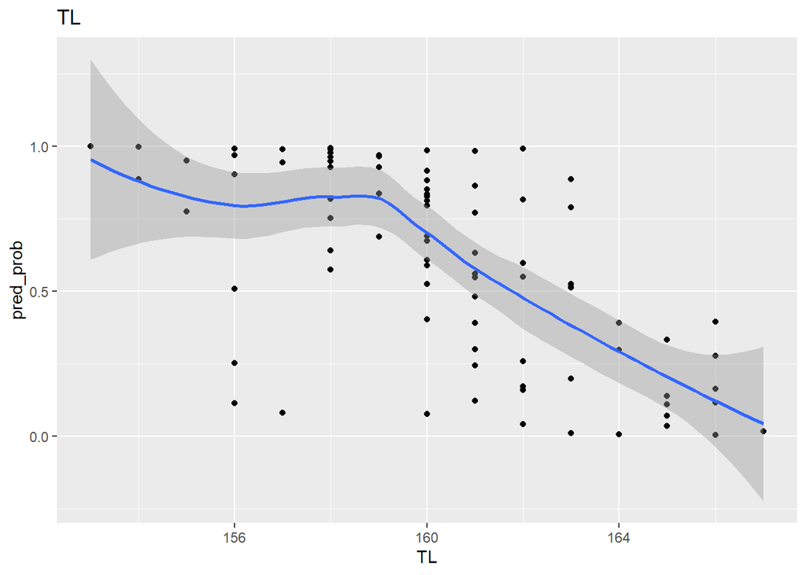

```r
bumpus$pred_prob <- predict(mymodel_red, type = "response")

#TL
ggplot(bumpus, aes(x = TL, y = pred_prob)) +
  geom_point() +
  geom_smooth(method = "loess")+
  labs(title = "TL")
```

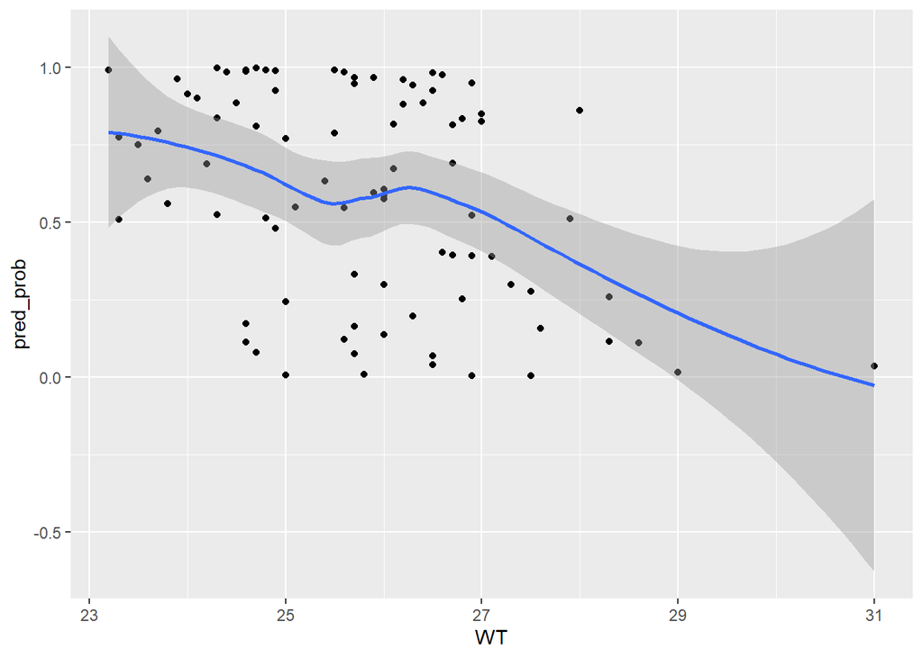

```r
#WT
ggplot(bumpus, aes(x = WT, y = pred_prob)) +
  geom_point() +
  geom_smooth(method = "loess") +
  labs(titel = "WT")
```

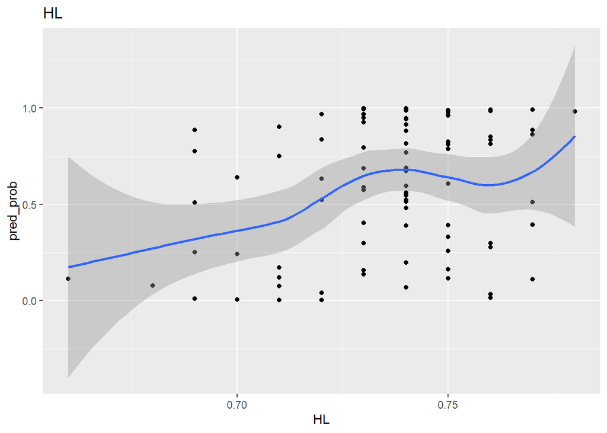

```r
#HL
ggplot(bumpus, aes(x = HL, y = pred_prob)) +
  geom_point() +
  geom_smooth(method = "loess") +
  labs(title = "HL")
```

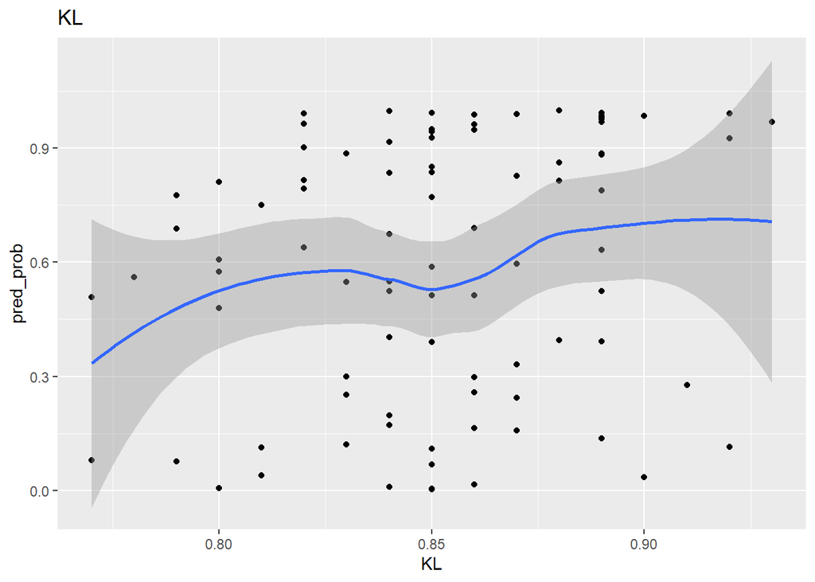

```r
#KL
ggplot(bumpus, aes(x = KL, y = pred_prob)) +
  geom_point() +
  geom_smooth(method = "loess") +
  labs(title = "KL")
```

## Exercise 3: Breast Cancer Diagnostic

The data set downloaded from the internet, contains measures obtain from tumor tissue in a cancer lab. The golden standard to diagnosing cancer is that an expert looks under a microscope, takes additional measurements, and makes a final call on whether the tumor is cancerous (malignant) or not (benign). The question is, can a predictive model effectively predict the gold standard using just the measurements alone. If so, this could effectively eliminate user error due to fatigue or distraction. The data set is loaded here and divided into a training and validation set:

```r
bc<-read.table("https://archive.ics.uci.edu/ml/machine-learning-databases/breast-cancer-wisconsin/wdbc.data",header=F,sep=",")
names(bc)<- c('id_number', 'diagnosis', 'radius_mean',
              'texture_mean', 'perimeter_mean', 'area_mean',
              'smoothness_mean', 'compactness_mean',
              'concavity_mean','concave_points_mean',
              'symmetry_mean', 'fractal_dimension_mean',
              'radius_se', 'texture_se', 'perimeter_se',
              'area_se', 'smoothness_se', 'compactness_se',
              'concavity_se', 'concave_points_se',
              'symmetry_se', 'fractal_dimension_se',
              'radius_worst', 'texture_worst',
              'perimeter_worst', 'area_worst',
              'smoothness_worst', 'compactness_worst',
              'concavity_worst', 'concave_points_worst',
              'symmetry_worst', 'fractal_dimension_worst')

#Getting a look at the distribution of the response
table(bc$diagnosis)
```

```
##
##   B   M
## 357 212
```

```r
#Train/Validation Split
library(caret)
set.seed(1234)
trainIndex<-createDataPartition(bc$diagnosis,p=.5,list=F)  #p: proportion of data in train

training<-bc[trainIndex,]
validate<-bc[-trainIndex,]
```

### A. The predictors in this data set are highly correlated. Because this exercise really only cares about prediction, we can worry less about this. Feature selection techniques such as GLMNET tend to dampen multicollinearity in the model as well. Train a GLMNET model using 10-fold CV on the training data. You may use the logloss or AUROC curve error metrics. Comment on which predictors were left or dropped, whichever is shorter.

```r
library(glmnet)
x <- model.matrix(diagnosis ~ . - 1, data = training)
y <- ifelse(training$diagnosis == "M", 1, 0)
cvfit <- cv.glmnet(x, y, family = "binomial", type.measure = "auc", nfolds = 10)
coef(cvfit, s = "lambda.min")
```

```
## 32 x 1 sparse Matrix of class "dgCMatrix"
##                            lambda.min
## (Intercept)             -2.389153e+01
## id_number                .
## radius_mean              .
## texture_mean             3.100611e-03
## perimeter_mean           .
## area_mean                .
## smoothness_mean          .
## compactness_mean         .
## concavity_mean           .
## concave_points_mean      2.368213e+01
## symmetry_mean            .
## fractal_dimension_mean   .
## radius_se                8.387474e+00
## texture_se               .
## perimeter_se             .
## area_se                  .
## smoothness_se            .
## compactness_se          -3.360123e+01
## concavity_se             .
## concave_points_se        .
## symmetry_se              .
## fractal_dimension_se    -1.475653e+02
## radius_worst             .
## texture_worst            1.759731e-01
## perimeter_worst          7.895363e-02
## area_worst               .
## smoothness_worst         1.083416e+01
## compactness_worst        .
## concavity_worst          1.505539e+00
## concave_points_worst     2.553342e+01
## symmetry_worst           8.102967e+00
## fractal_dimension_worst  .
```

Texture_mean, concave_points_mean, radius_se, compactness_se, fractal_dimension_se, texture_worst, perimeter_worst, smoothness_worst, concavity_worst, concave_points_worst, and symmetry_worst were kept in the final model.

2. For comparisons, train a KNN model under the same CV settings as part A. Provide an ROC curve with both models overlayed. Do the models curves behave similarly or not? Report the two models AUROC values as well.

```r
library(class)
library(pROC)
# Create matrices (drop ID and diagnosis)
train_x <- as.matrix(training[, !(names(training) %in% c("id_number", "diagnosis"))])
train_y <- as.factor(training$diagnosis)
validate_x <- as.matrix(validate[, !(names(validate) %in% c("id_number", "diagnosis"))])
validate_y <- as.factor(validate$diagnosis)

k <- 5
knn_pred <- knn(train = train_x, test = validate_x, cl = train_y, k = k, prob = TRUE)

# Extract probability for positive class ("M")
knn_probs <- ifelse(knn_pred == "M", attr(knn_pred, "prob"), 1 - attr(knn_pred, "prob"))


validate_x <- model.matrix(diagnosis ~ . - 1, data = validate)
glmnet_probs <- predict(cvfit, newx = validate_x, s = "lambda.min", type = "response")


roc_glmnet <- roc(validate_y, as.numeric(glmnet_probs))
roc_knn <- roc(validate_y, as.numeric(knn_probs))
```

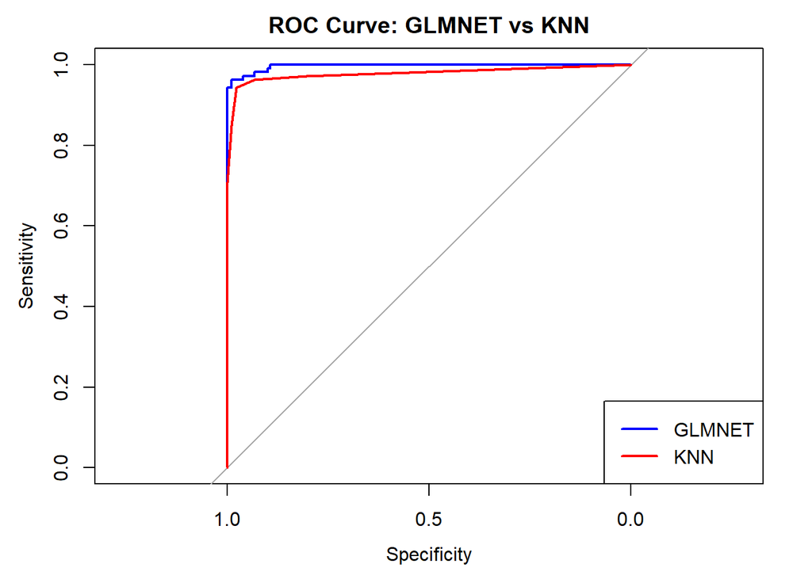

```r
# Plot overlayed ROC curves
plot(roc_glmnet, col="blue", main="ROC Curve: GLMNET vs KNN")
lines(roc_knn, col="red")
legend("bottomright", legend=c("GLMNET","KNN"), col=c("blue","red"), lwd=2)
```

```r
# AUROC values
auc_glmnet <- auc(roc_glmnet)
auc_knn <- auc(roc_knn)

print(auc_glmnet)
```

```
## Area under the curve: 0.9968
```

```r
print(auc_knn)
```

```
## Area under the curve: 0.9786
```

The models to behave similarly

### C. Compute the full confusion matrices using the best threshold provided by the ROC curve functions. No commentary is needed I just want you to practice thresholding again. It has been a while. Just note that when choosing a threshold this way we are not taking into account the prevalence (see unit 9 discussions)

```r
library(glmnet)
library(class)
library(pROC)

# Prepare matrices and responses
train_x <- as.matrix(training[, !(names(training) %in% c("id_number", "diagnosis"))])
train_y <- as.factor(training$diagnosis)
validate_x <- as.matrix(validate[, !(names(validate) %in% c("id_number", "diagnosis"))])
validate_y <- as.factor(validate$diagnosis)

# KNN predictions
k <- 5
knn_pred <- knn(train = train_x, test = validate_x, cl = train_y, k = k, prob = TRUE)
knn_probs <- ifelse(knn_pred == "M", attr(knn_pred, "prob"), 1 - attr(knn_pred, "prob"))

# GLMNET predictions (use same columns as model.matrix for both sets!)
validate_x2 <- model.matrix(diagnosis ~ . - 1, data = validate)
glmnet_probs <- predict(cvfit, newx = validate_x2, s = "lambda.min", type = "response")
glmnet_probs <- as.numeric(glmnet_probs)

# Get thresholds
best_thresh_glmnet <- coords(roc_glmnet, "best", ret = "threshold")
best_thresh_glmnet_num <- best_thresh_glmnet[1, 1]   # or as.numeric(best_thresh_glmnet)
best_thresh_knn <- coords(roc_knn, "best", ret = "threshold")
best_thresh_knn_num <- best_thresh_knn[1, 1]

# Predicted values
glmnet_preds <- ifelse(glmnet_probs > best_thresh_glmnet_num, "M", "B")
knn_preds <- ifelse(knn_probs > best_thresh_knn_num, "M", "B")

# Double check lengths
stopifnot(length(glmnet_preds) == length(validate_y))
stopifnot(length(knn_preds) == length(validate_y))

# Confusion matrices
table(Predicted = glmnet_preds, Actual = validate_y)
```

```
##          Actual
## Predicted   B   M
##         B 176   4
##         M   2 102
```

```r
table(Predicted = knn_preds, Actual = validate_y)
```

```
##          Actual
## Predicted   B   M
##         B 174   6
##         M   4 100
```